# Polymarket Bias & Mispricing Analysis

Closed Markets 2025 — Calibration & Category Mispricings

Laurence Pacher

2026-02-18

# 1 · Setup & Data Loading

```r
library(arrow)
library(dplyr)
library(tidyr)
library(stringr)
library(ggplot2)
library(jsonlite)
library(lubridate)
library(scales)
library(purrr)

theme_poly <- theme_minimal(base_size = 13) +
  theme(
    plot.title    = element_text(face = "bold", size = 15),
    plot.subtitle = element_text(color = "grey40"),
    panel.grid.minor = element_blank(),
    legend.position = "bottom"
  )
theme_set(theme_poly)
```

```r
# ── Markets master table ─────────────────────────────────────────────
df <- read_parquet("../data/markets_2025_index.parquet")

cat(nrow(df), "market rows loaded\n")
```

```
## 111178 market rows loaded
```

```r
cat(ncol(df), "columns\n")
```

```
## 87 columns
```

## 1.1 Parse Resolutions & Token Mapping

We need to know (a) which token is the “Yes” token and (b) whether that outcome resolved to 1.

```r
# Helper: safely parse JSON arrays from Polymarket columns
safe_parse_json <- function(x) {
  tryCatch(fromJSON(x), error = function(e) NA)
}

# Parse outcomes, prices, and token IDs
df_parsed <- df %>%
  filter(closed == TRUE) %>%
  rowwise() %>%
  mutate(
    outcomes_list = list(tryCatch(fromJSON(outcomes), error = function(e) NA_character_)),
    prices_list   = list(tryCatch(fromJSON(outcome_prices), error = function(e) NA_character_)),
    tokens_list   = list(tryCatch(fromJSON(token_ids), error = function(e) NA_character_))
  ) %>%
  ungroup()

# Extract Yes token info for binary markets
df_binary <- df_parsed %>%
  mutate(
    n_outcomes    = lengths(outcomes_list),
    is_binary     = n_outcomes == 2,
    yes_idx       = map_int(outcomes_list, ~ {
      idx <- which(tolower(.x) == "yes")
      if (length(idx) == 1) idx else NA_integer_
    })
  ) %>%
  filter(is_binary, !is.na(yes_idx)) %>%
  mutate(
    yes_token_id   = map2_chr(tokens_list, yes_idx, ~ .x[.y]),
    yes_resolution = map2_dbl(prices_list, yes_idx, ~ as.numeric(.x[.y])),
    no_idx         = ifelse(yes_idx == 1, 2, 1),
    no_token_id    = map2_chr(tokens_list, no_idx, ~ .x[.y])
  ) %>%
  filter(!is.na(yes_resolution), yes_resolution %in% c(0, 1))

cat(nrow(df_binary), "binary Yes/No markets with clean resolution\n")
```

```
## 49753 binary Yes/No markets with clean resolution
```

```r
cat("Resolution rate (Yes = 1):", round(mean(df_binary$yes_resolution), 3), "\n")
```

```
## Resolution rate (Yes = 1): 0.267
```

## 1.2 Derive Categories from Tags

```r
# Define category keywords (order matters — first match wins)
category_rules <- tibble::tribble(
  ~category,        ~pattern,
  "Sports",         "nba|nfl|mlb|nhl|soccer|football|tennis|boxing|mma|ufc|cricket|esports|dota|league of legends|sports|epl|la liga|bundesliga|serie a|ligue 1|f1|formula|nascar|golf|olympics|pga",
  "Crypto",         "crypto|bitcoin|btc|ethereum|eth|solana|sol|defi|blockchain|token|nft|altcoin|memecoin|binance|coinbase",
  "Politics",       "politic|election|trump|biden|democrat|republican|congress|senate|governor|president|vote|gop|dnc|rnc|parliament|minister|legislation|bill|law|executive order",
  "Economics",      "econom|fed |federal reserve|interest rate|inflation|gdp|employment|jobs|recession|tariff|trade|stock market|s&p|nasdaq|dow jones|treasury|debt|cpi",
  "Science/Tech",   "science|tech|ai |artificial intelligence|openai|google|apple|microsoft|space|spacex|nasa|climate|weather|earthquake|hurricane|temperature",
  "Entertainment",  "movie|film|oscar|grammy|emmy|music|album|box office|streaming|netflix|youtube|tiktok|celebrity|award|tv show|series",
  "World Events",   "war|conflict|ukraine|russia|china|israel|gaza|nato|united nations|refugee|disaster|pandemic",
  "Other",          ".*"
)

assign_category <- function(tags, series_slug = NA_character_) {
  if (is.na(tags) || tags == "") return("Other")
  combined <- tolower(tags)
  for (i in seq_len(nrow(category_rules))) {
    if (str_detect(combined, category_rules$pattern[i])) {
      return(category_rules$category[i])
    }
  }
  return("Other")
}

df_binary <- df_binary %>%
  mutate(category = map_chr(event_tags, assign_category))

cat("\n── Category distribution ──\n")
```

```
##
## ── Category distribution ──
```

```r
df_binary %>% count(category, sort = TRUE) %>% print()
```

```
## # A tibble: 8 × 2
##   category          n
##   <chr>         <int>
## 1 Sports        14881
## 2 Crypto        14161
## 3 Politics       9844
## 4 Science/Tech   5570
## 5 Other          2410
## 6 Entertainment  2091
## 7 Economics       777
## 8 World Events     19
```

# 2 · Calibration Analysis (Snapshot Prices)

The core question: **When the market prices a Yes token at probability $p$, does the event actually happen $p$% of the time?**

We use the price history to sample market prices at fixed intervals before resolution, then check calibration.

```r
# ── Build lookup table for Yes tokens ────────────────────────────────
token_lookup <- df_binary %>%
  select(yes_token_id, yes_resolution, id, event_title, category,
         closed_time, volume_num) %>%
  rename(token_id = yes_token_id) %>%
  mutate(closed_dt = ymd_hms(closed_time, quiet = TRUE)) %>%
  filter(!is.na(closed_dt))

yes_tokens <- unique(token_lookup$token_id)
cat(length(yes_tokens), "unique Yes tokens to look up\n")
```

```
## 49753 unique Yes tokens to look up
```

```r
# ── Process price history in BATCHES to avoid long-vector crash ──────
# Strategy: split tokens into chunks, collect + compute per chunk,
# then rbind only the small snapshot results.

dfp_arrow <- open_dataset(
  "../data/markets_2025_closed_price_history.parquet"
)

snapshots      <- c(1, 6, 24, 72, 168, 720)
snapshot_labels <- c("1h", "6h", "1d", "3d", "1w", "1mo")

BATCH_SIZE <- 500
token_batches <- split(yes_tokens, ceiling(seq_along(yes_tokens) / BATCH_SIZE))
cat(length(token_batches), "batches of up to", BATCH_SIZE, "tokens\n")
```

```
## 100 batches of up to 500 tokens
```

```r
get_snapshot_price <- function(hbc, price, target_hours) {
  diffs <- abs(hbc - target_hours)
  valid <- diffs < (target_hours * 0.5 + 1)
  if (!any(valid)) return(NA_real_)
  price[valid][which.min(diffs[valid])]
}

snapshot_list <- vector("list", length(token_batches))

for (i in seq_along(token_batches)) {
  batch_tokens <- token_batches[[i]]

  # Collect only this batch from Arrow
  batch_prices <- dfp_arrow %>%
    filter(token_id %in% batch_tokens) %>%
    select(token_id, timestamp, price) %>%
    collect()

  if (nrow(batch_prices) == 0) next

  # Join resolution info
  batch_prices <- batch_prices %>%
    inner_join(
      token_lookup %>% select(token_id, yes_resolution, id, category,
                               volume_num, closed_dt),
      by = "token_id"
    ) %>%
    mutate(hours_before_close = as.numeric(
      difftime(closed_dt, timestamp, units = "hours")
    )) %>%
    filter(hours_before_close >= 0)

  if (nrow(batch_prices) == 0) next

  # Compute snapshot prices per market
  batch_snap <- batch_prices %>%
    group_by(token_id, id, yes_resolution, category, volume_num) %>%
    summarise(
      across_snapshots = list(tibble(
        snapshot_hours = snapshots,
        snapshot_label = snapshot_labels,
        snap_price = map_dbl(snapshots, ~ get_snapshot_price(
          hours_before_close, price, .x
        ))
      )),
      .groups = "drop"
    ) %>%
    unnest(across_snapshots) %>%
    filter(!is.na(snap_price))

  snapshot_list[[i]] <- batch_snap

  if (i %% 5 == 0 || i == length(token_batches)) {
    cat(sprintf("  Batch %d/%d done (%d snapshot rows so far)\n",
                i, length(token_batches),
                sum(map_int(snapshot_list, ~ if(is.null(.x)) 0L else nrow(.x)))))
  }

  rm(batch_prices, batch_snap); gc(verbose = FALSE)
}
```

```
##   Batch 5/100 done (11595 snapshot rows so far)
##   Batch 10/100 done (23809 snapshot rows so far)
##   Batch 15/100 done (36470 snapshot rows so far)
##   Batch 20/100 done (48962 snapshot rows so far)
##   Batch 25/100 done (61591 snapshot rows so far)
##   Batch 30/100 done (74504 snapshot rows so far)
##   Batch 35/100 done (87249 snapshot rows so far)
##   Batch 40/100 done (100113 snapshot rows so far)
##   Batch 45/100 done (112551 snapshot rows so far)
##   Batch 50/100 done (123420 snapshot rows so far)
##   Batch 55/100 done (133622 snapshot rows so far)
##   Batch 60/100 done (145422 snapshot rows so far)
##   Batch 65/100 done (157735 snapshot rows so far)
##   Batch 70/100 done (169985 snapshot rows so far)
##   Batch 75/100 done (181988 snapshot rows so far)
##   Batch 80/100 done (194828 snapshot rows so far)
##   Batch 85/100 done (207703 snapshot rows so far)
##   Batch 90/100 done (220378 snapshot rows so far)
##   Batch 95/100 done (232904 snapshot rows so far)
##   Batch 100/100 done (245827 snapshot rows so far)
```

```r
snapshot_data <- bind_rows(snapshot_list)
rm(snapshot_list, dfp_arrow); gc()
```

```
##            used  (Mb) gc trigger  (Mb)  max used  (Mb)
## Ncells  3499346 186.9    5750472 307.2   5750472 307.2
## Vcells 42131714 321.5  121330323 925.7 121329831 925.7
```

```r
cat("\n", nrow(snapshot_data), "total market × snapshot observations\n")
```

```
##
##  245827 total market × snapshot observations
```

## 2.1 Overall Calibration Curve

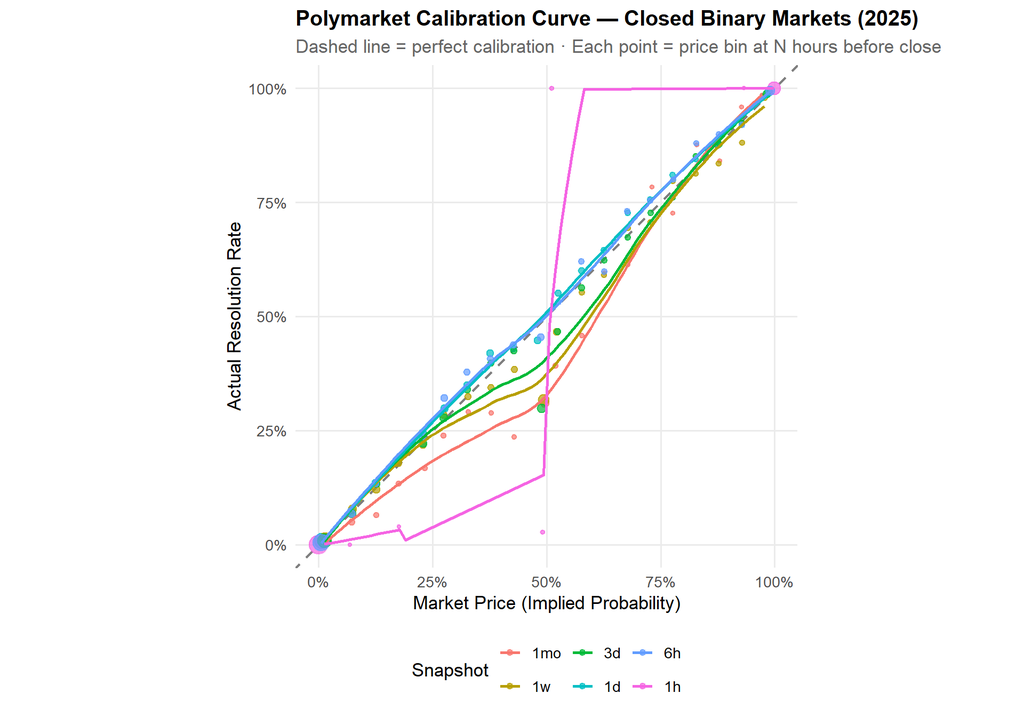

```r
# Bin prices into deciles for each snapshot
calibration <- snapshot_data %>%
  mutate(
    price_bin = cut(snap_price, breaks = seq(0, 1, by = 0.05),
                    include.lowest = TRUE, labels = FALSE),
    bin_midpoint = (price_bin - 1) * 0.05 + 0.025
  ) %>%
  filter(!is.na(price_bin)) %>%
  group_by(snapshot_label, bin_midpoint) %>%
  summarise(
    n          = n(),
    actual_pct = mean(yes_resolution),
    avg_price  = mean(snap_price),
    .groups    = "drop"
  ) %>%
  # Set factor order for snapshots

  mutate(snapshot_label = factor(snapshot_label,
                                 levels = c("1mo", "1w", "3d", "1d", "6h", "1h")))

ggplot(calibration %>% filter(n >= 20),
       aes(x = avg_price, y = actual_pct)) +
  geom_abline(slope = 1, intercept = 0, linetype = "dashed", color = "grey50", linewidth = 0.8) +
  geom_point(aes(size = n, color = snapshot_label), alpha = 0.7) +
  geom_smooth(aes(color = snapshot_label, weight = n), method = "loess",
              se = FALSE, linewidth = 1) +
  scale_x_continuous(labels = percent, limits = c(0, 1)) +
  scale_y_continuous(labels = percent, limits = c(0, 1)) +
  scale_size_continuous(range = c(1, 6), guide = "none") +
  labs(
    title    = "Polymarket Calibration Curve — Closed Binary Markets (2025)",
    subtitle = "Dashed line = perfect calibration · Each point = price bin at N hours before close",
    x = "Market Price (Implied Probability)",
    y = "Actual Resolution Rate",
    color = "Snapshot"
  ) +
  coord_equal()
```

## 2.2 Calibration Error by Snapshot Horizon

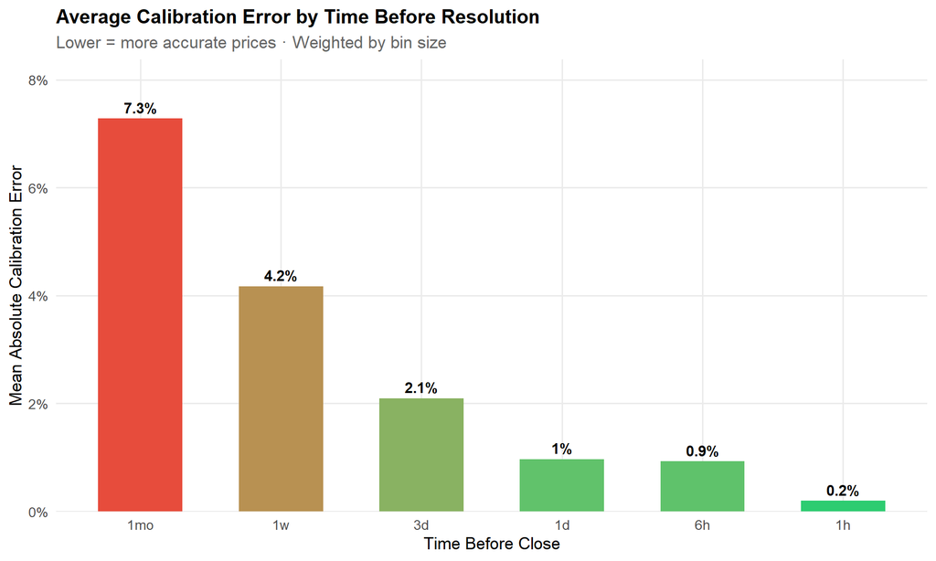

```r
# Brier-style calibration error per snapshot
cal_error <- snapshot_data %>%
  mutate(price_bin = round(snap_price * 20) / 20) %>%  # 5% bins
  group_by(snapshot_label, price_bin) %>%
  summarise(
    n = n(),
    actual = mean(yes_resolution),
    predicted = mean(snap_price),
    .groups = "drop"
  ) %>%
  filter(n >= 10) %>%
  group_by(snapshot_label) %>%
  summarise(
    weighted_cal_error = weighted.mean(abs(actual - predicted), w = n),
    n_bins = n(),
    total_obs = sum(n),
    .groups = "drop"
  ) %>%
  mutate(snapshot_label = factor(snapshot_label,
                                  levels = c("1mo", "1w", "3d", "1d", "6h", "1h")))

ggplot(cal_error, aes(x = snapshot_label, y = weighted_cal_error)) +
  geom_col(aes(fill = weighted_cal_error), width = 0.6, show.legend = FALSE) +
  geom_text(aes(label = paste0(round(weighted_cal_error * 100, 1), "%")),
            vjust = -0.5, fontface = "bold", size = 4) +
  scale_fill_gradient(low = "#2ecc71", high = "#e74c3c") +
  scale_y_continuous(labels = percent, expand = expansion(mult = c(0, 0.15))) +
  labs(
    title = "Average Calibration Error by Time Before Resolution",
    subtitle = "Lower = more accurate prices · Weighted by bin size",
    x = "Time Before Close", y = "Mean Absolute Calibration Error"
  )
```

## 2.3 Favorite–Longshot Bias (within Calibration)

Even if overall calibration looks good, a **favorite–longshot bias** means longshots (low probability) are overpriced and favorites (high probability) are underpriced — or vice versa.

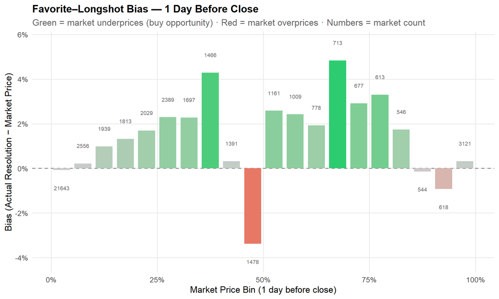

```r
# Use 1-day-before-close snapshot for cleanest signal
fl_data <- snapshot_data %>%
  filter(snapshot_label == "1d") %>%
  mutate(
    price_bin = cut(snap_price, breaks = seq(0, 1, by = 0.05),
                    include.lowest = TRUE, labels = FALSE),
    bin_midpoint = (price_bin - 1) * 0.05 + 0.025
  ) %>%
  filter(!is.na(price_bin)) %>%
  group_by(bin_midpoint) %>%
  summarise(
    n = n(),
    actual = mean(yes_resolution),
    predicted = mean(snap_price),
    bias = actual - predicted,  # positive = underpriced (actual > market price)
    .groups = "drop"
  )

ggplot(fl_data %>% filter(n >= 15), aes(x = bin_midpoint, y = bias)) +
  geom_hline(yintercept = 0, linetype = "dashed", color = "grey50") +
  geom_col(aes(fill = bias), width = 0.04, show.legend = FALSE) +
  geom_text(aes(label = n, y = ifelse(bias >= 0, bias + 0.008, bias - 0.008)),
            size = 2.8, color = "grey40") +
  scale_fill_gradient2(low = "#e74c3c", mid = "grey80", high = "#2ecc71", midpoint = 0) +
  scale_x_continuous(labels = percent) +
  scale_y_continuous(labels = percent) +
  labs(
    title    = "Favorite–Longshot Bias — 1 Day Before Close",
    subtitle = "Green = market underprices (buy opportunity) · Red = market overprices · Numbers = market count",
    x = "Market Price Bin (1 day before close)",
    y = "Bias (Actual Resolution − Market Price)"
  )
```

# 3 · Category-Level Mispricings

## 3.1 Category Calibration Curves

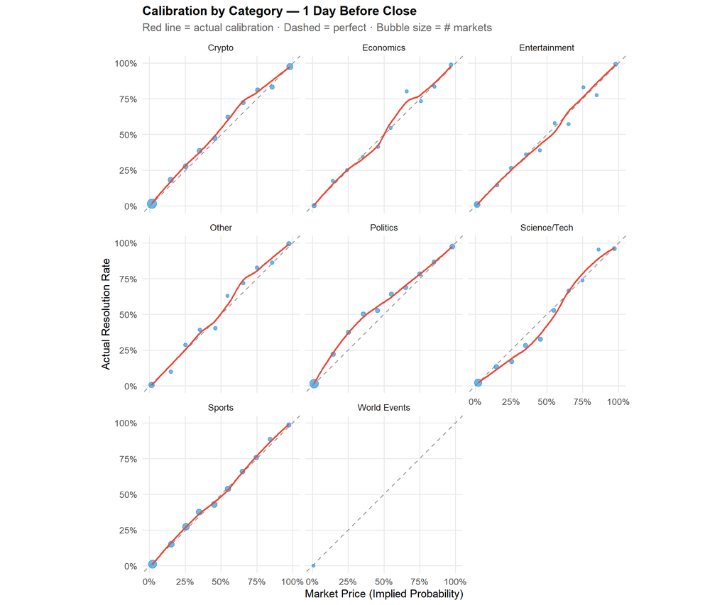

```r
# Use 1-day snapshot for category analysis
cat_cal <- snapshot_data %>%
  filter(snapshot_label == "1d") %>%
  mutate(
    price_bin = cut(snap_price, breaks = seq(0, 1, by = 0.10),
                    include.lowest = TRUE, labels = FALSE),
    bin_midpoint = (price_bin - 1) * 0.10 + 0.05
  ) %>%
  filter(!is.na(price_bin)) %>%
  group_by(category, bin_midpoint) %>%
  summarise(
    n      = n(),
    actual = mean(yes_resolution),
    predicted = mean(snap_price),
    .groups = "drop"
  )

ggplot(cat_cal %>% filter(n >= 10),
       aes(x = predicted, y = actual)) +
  geom_abline(slope = 1, intercept = 0, linetype = "dashed", color = "grey60") +
  geom_point(aes(size = n), color = "#3498db", alpha = 0.7) +
  geom_smooth(aes(weight = n), method = "loess", se = FALSE,
              color = "#e74c3c", linewidth = 1) +
  facet_wrap(~ category, ncol = 3) +
  scale_x_continuous(labels = percent, limits = c(0, 1)) +
  scale_y_continuous(labels = percent, limits = c(0, 1)) +
  scale_size_continuous(range = c(1.5, 5), guide = "none") +
  coord_equal() +
  labs(
    title = "Calibration by Category — 1 Day Before Close",
    subtitle = "Red line = actual calibration · Dashed = perfect · Bubble size = # markets",
    x = "Market Price (Implied Probability)",
    y = "Actual Resolution Rate"
  )
```

## 3.2 Category Bias Heatmap

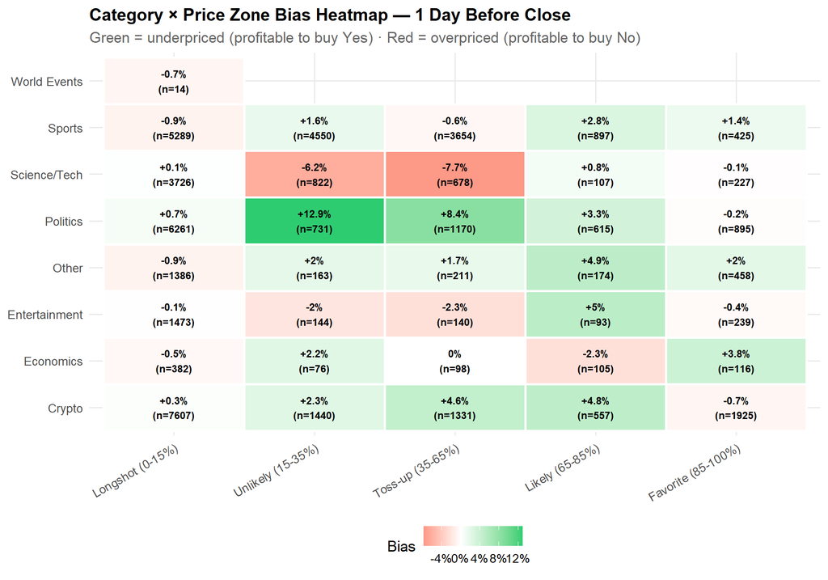

```r
cat_bias <- snapshot_data %>%
  filter(snapshot_label == "1d") %>%
  mutate(
    price_zone = case_when(
      snap_price <= 0.15 ~ "Longshot (0-15%)",
      snap_price <= 0.35 ~ "Unlikely (15-35%)",
      snap_price <= 0.65 ~ "Toss-up (35-65%)",
      snap_price <= 0.85 ~ "Likely (65-85%)",
      TRUE               ~ "Favorite (85-100%)"
    ),
    price_zone = factor(price_zone, levels = c(
      "Longshot (0-15%)", "Unlikely (15-35%)", "Toss-up (35-65%)",
      "Likely (65-85%)", "Favorite (85-100%)"
    ))
  ) %>%
  group_by(category, price_zone) %>%
  summarise(
    n    = n(),
    bias = mean(yes_resolution) - mean(snap_price),
    .groups = "drop"
  ) %>%
  filter(n >= 10)

ggplot(cat_bias, aes(x = price_zone, y = category, fill = bias)) +
  geom_tile(color = "white", linewidth = 1) +
  geom_text(aes(label = paste0(ifelse(bias > 0, "+", ""),
                                round(bias * 100, 1), "%\n(n=", n, ")")),
            size = 3.2, fontface = "bold") +
  scale_fill_gradient2(
    low = "#e74c3c", mid = "white", high = "#2ecc71", midpoint = 0,
    labels = percent, name = "Bias"
  ) +
  labs(
    title    = "Category × Price Zone Bias Heatmap — 1 Day Before Close",
    subtitle = "Green = underpriced (profitable to buy Yes) · Red = overpriced (profitable to buy No)",
    x = NULL, y = NULL
  ) +
  theme(axis.text.x = element_text(angle = 30, hjust = 1))
```

## 3.3 Aggregate Category Bias & Brier Score

```r
cat_stats <- snapshot_data %>%
  filter(snapshot_label == "1d") %>%
  group_by(category) %>%
  summarise(
    n_markets       = n(),
    avg_price       = mean(snap_price),
    resolution_rate = mean(yes_resolution),
    bias            = mean(yes_resolution) - mean(snap_price),
    brier_score     = mean((snap_price - yes_resolution)^2),
    abs_bias        = mean(abs(yes_resolution - snap_price)),
    .groups = "drop"
  ) %>%
  arrange(desc(abs(bias)))

cat_stats %>%
  mutate(across(where(is.numeric), ~ round(.x, 4))) %>%
  knitr::kable(caption = "Category-Level Bias & Accuracy (1 day before close)")
```

Category-Level Bias & Accuracy (1 day before close)

| category | n_markets | avg_price | resolution_rate | bias | brier_score | abs_bias |
| --- | --- | --- | --- | --- | --- | --- |
| World Events | 18 | 0.1137 | 0.2222 | 0.1085 | 0.0650 | 0.1193 |
| Politics | 9672 | 0.2265 | 0.2529 | 0.0264 | 0.0755 | 0.1431 |
| Science/Tech | 5560 | 0.1656 | 0.1480 | -0.0176 | 0.0743 | 0.1533 |
| Crypto | 12860 | 0.2694 | 0.2796 | 0.0102 | 0.0732 | 0.1438 |
| Other | 2392 | 0.3098 | 0.3148 | 0.0050 | 0.0554 | 0.1200 |
| Sports | 14815 | 0.2823 | 0.2846 | 0.0022 | 0.1407 | 0.2826 |
| Economics | 777 | 0.3403 | 0.3423 | 0.0020 | 0.0846 | 0.1735 |
| Entertainment | 2089 | 0.2061 | 0.2044 | -0.0017 | 0.0473 | 0.0972 |

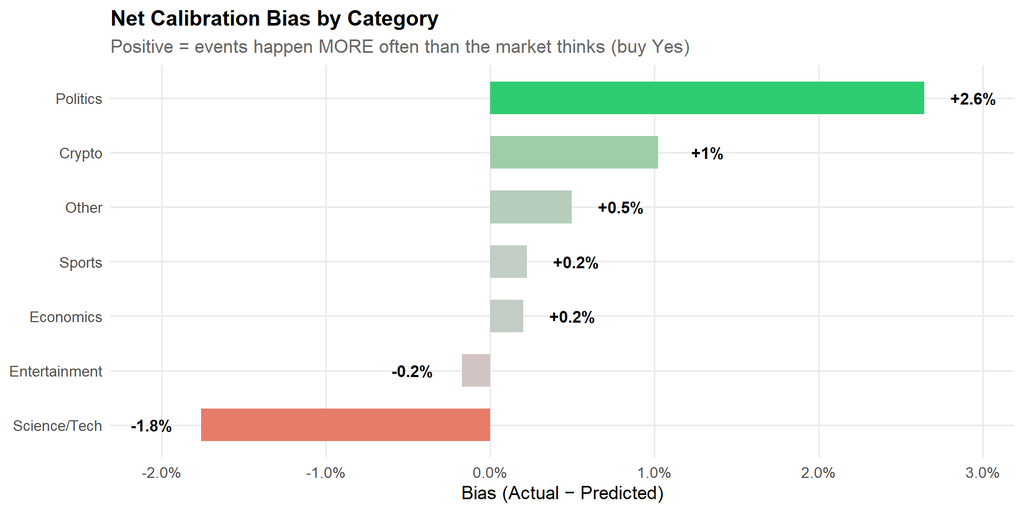

```r
ggplot(cat_stats %>% filter(n_markets >= 20),
       aes(x = reorder(category, bias), y = bias)) +
  geom_col(aes(fill = bias), width = 0.6, show.legend = FALSE) +
  geom_text(aes(label = paste0(ifelse(bias > 0, "+", ""),
                                round(bias * 100, 1), "%"),
                y = bias + sign(bias) * 0.003),
            fontface = "bold", size = 4) +
  scale_fill_gradient2(low = "#e74c3c", mid = "grey80", high = "#2ecc71", midpoint = 0) +
  scale_y_continuous(labels = percent) +
  coord_flip() +
  labs(
    title    = "Net Calibration Bias by Category",
    subtitle = "Positive = events happen MORE often than the market thinks (buy Yes)",
    x = NULL, y = "Bias (Actual − Predicted)"
  )
```

# 4 · Volume-Weighted Analysis

Thin markets are noisier. Let’s check if bias patterns change when we weight by volume.

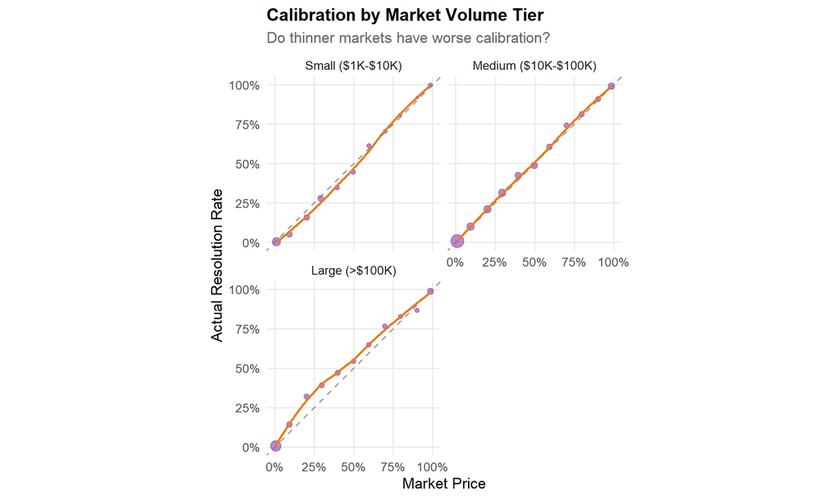

```r
vol_cal <- snapshot_data %>%
  filter(snapshot_label == "1d", !is.na(volume_num)) %>%
  mutate(
    vol_tier = case_when(
      volume_num < 1000    ~ "Micro (<$1K)",
      volume_num < 10000   ~ "Small ($1K-$10K)",
      volume_num < 100000  ~ "Medium ($10K-$100K)",
      TRUE                 ~ "Large (>$100K)"
    ),
    vol_tier = factor(vol_tier, levels = c(
      "Micro (<$1K)", "Small ($1K-$10K)", "Medium ($10K-$100K)", "Large (>$100K)"
    )),
    price_bin = round(snap_price * 10) / 10
  ) %>%
  group_by(vol_tier, price_bin) %>%
  summarise(
    n      = n(),
    actual = mean(yes_resolution),
    predicted = mean(snap_price),
    .groups = "drop"
  )

ggplot(vol_cal %>% filter(n >= 10),
       aes(x = predicted, y = actual)) +
  geom_abline(slope = 1, intercept = 0, linetype = "dashed", color = "grey60") +
  geom_point(aes(size = n), color = "#9b59b6", alpha = 0.7) +
  geom_smooth(aes(weight = n), method = "loess", se = FALSE,
              color = "#e67e22", linewidth = 1) +
  facet_wrap(~ vol_tier, ncol = 2) +
  scale_x_continuous(labels = percent, limits = c(0, 1)) +
  scale_y_continuous(labels = percent, limits = c(0, 1)) +
  scale_size_continuous(range = c(1, 5), guide = "none") +
  coord_equal() +
  labs(
    title = "Calibration by Market Volume Tier",
    subtitle = "Do thinner markets have worse calibration?",
    x = "Market Price", y = "Actual Resolution Rate"
  )
```

```r
vol_brier <- snapshot_data %>%
  filter(snapshot_label == "1d", !is.na(volume_num)) %>%
  mutate(
    vol_tier = case_when(
      volume_num < 1000    ~ "Micro (<$1K)",
      volume_num < 10000   ~ "Small ($1K-$10K)",
      volume_num < 100000  ~ "Medium ($10K-$100K)",
      TRUE                 ~ "Large (>$100K)"
    ),
    vol_tier = factor(vol_tier, levels = c(
      "Micro (<$1K)", "Small ($1K-$10K)", "Medium ($10K-$100K)", "Large (>$100K)"
    )),
    brier = (snap_price - yes_resolution)^2
  ) %>%
  group_by(vol_tier) %>%
  summarise(
    n = n(),
    brier_score = mean(brier),
    bias = mean(yes_resolution - snap_price),
    .groups = "drop"
  )

vol_brier %>%
  mutate(across(where(is.numeric) & !n, ~ round(.x, 4))) %>%
  knitr::kable(caption = "Brier Score & Bias by Volume Tier")
```

Brier Score & Bias by Volume Tier

| vol_tier | n | brier_score | bias |
| --- | --- | --- | --- |
| Small ($1K-$10K) | 8650 | 0.0917 | -0.0188 |
| Medium ($10K-$100K) | 26440 | 0.0958 | 0.0058 |
| Large (>$100K) | 13093 | 0.0872 | 0.0263 |

# 5 · Exploitable Pattern Summary

```r
# Find the most exploitable category × price zone combos
exploitable <- snapshot_data %>%
  filter(snapshot_label == "1d") %>%
  mutate(
    price_zone = case_when(
      snap_price <= 0.15 ~ "Longshot (0-15%)",
      snap_price <= 0.35 ~ "Unlikely (15-35%)",
      snap_price <= 0.65 ~ "Toss-up (35-65%)",
      snap_price <= 0.85 ~ "Likely (65-85%)",
      TRUE               ~ "Favorite (85-100%)"
    )
  ) %>%
  group_by(category, price_zone) %>%
  summarise(
    n_markets   = n(),
    avg_price   = mean(snap_price),
    actual_rate = mean(yes_resolution),
    bias        = mean(yes_resolution) - mean(snap_price),
    edge_pct    = bias / avg_price * 100,  # % return on implied price
    brier       = mean((snap_price - yes_resolution)^2),
    .groups     = "drop"
  ) %>%
  filter(n_markets >= 15, abs(bias) > 0.03) %>%
  arrange(desc(abs(bias)))

exploitable %>%
  mutate(across(where(is.numeric) & !n_markets, ~ round(.x, 3))) %>%
  head(20) %>%
  knitr::kable(caption = "Top 20 Most Exploitable Category × Price Zone Combinations (|bias| > 3%, n ≥ 15)")
```

Top 20 Most Exploitable Category × Price Zone Combinations (|bias| > 3%, n ≥ 15)

| category | price_zone | n_markets | avg_price | actual_rate | bias | edge_pct | brier |
| --- | --- | --- | --- | --- | --- | --- | --- |
| Politics | Unlikely (15-35%) | 731 | 0.253 | 0.382 | 0.129 | 51.071 | 0.247 |
| Politics | Toss-up (35-65%) | 1170 | 0.502 | 0.586 | 0.084 | 16.802 | 0.247 |
| Science/Tech | Toss-up (35-65%) | 678 | 0.465 | 0.388 | -0.077 | -16.506 | 0.232 |
| Science/Tech | Unlikely (15-35%) | 822 | 0.251 | 0.189 | -0.062 | -24.751 | 0.155 |
| Entertainment | Likely (65-85%) | 93 | 0.756 | 0.806 | 0.050 | 6.656 | 0.152 |
| Other | Likely (65-85%) | 174 | 0.761 | 0.810 | 0.049 | 6.471 | 0.156 |
| Crypto | Likely (65-85%) | 557 | 0.751 | 0.799 | 0.048 | 6.371 | 0.164 |
| Crypto | Toss-up (35-65%) | 1331 | 0.482 | 0.527 | 0.046 | 9.444 | 0.243 |
| Economics | Favorite (85-100%) | 116 | 0.945 | 0.983 | 0.038 | 3.976 | 0.019 |
| Politics | Likely (65-85%) | 615 | 0.749 | 0.782 | 0.033 | 4.470 | 0.169 |

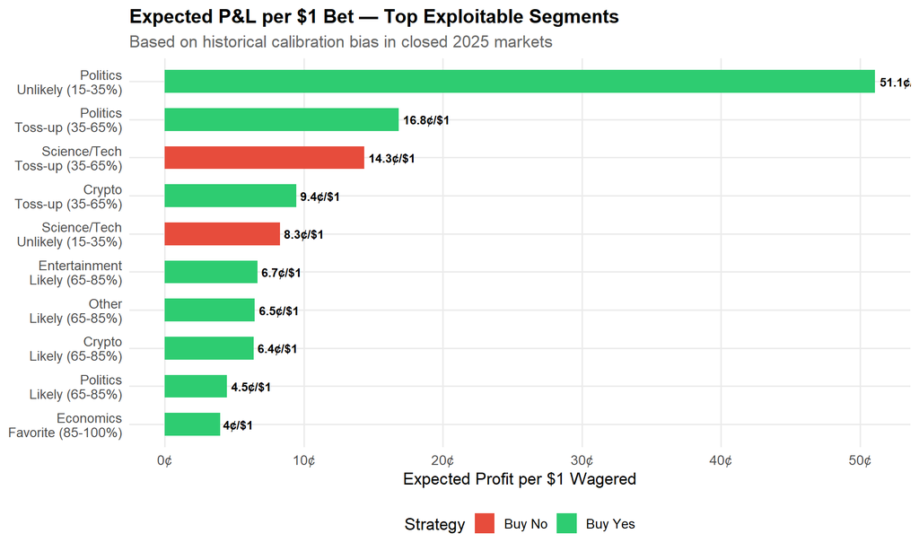

```r
# Simulated P&L if you always bet $1 on the bias direction
exploitable_pl <- exploitable %>%
  mutate(
    strategy = ifelse(bias > 0, "Buy Yes", "Buy No"),
    # Simplified expected P&L per $1 bet
    expected_pl = ifelse(bias > 0,
                         actual_rate * (1 / avg_price - 1) - (1 - actual_rate),
                         (1 - actual_rate) * (1 / (1 - avg_price) - 1) - actual_rate),
    label = paste(category, price_zone, sep = "\n")
  )

ggplot(exploitable_pl %>% head(15),
       aes(x = reorder(label, expected_pl), y = expected_pl)) +
  geom_col(aes(fill = strategy), width = 0.6) +
  geom_text(aes(label = paste0(round(expected_pl * 100, 1), "¢/$1")),
            hjust = ifelse(exploitable_pl$expected_pl[1:min(15, nrow(exploitable_pl))] >= 0, -0.1, 1.1),
            size = 3.3, fontface = "bold") +
  scale_fill_manual(values = c("Buy Yes" = "#2ecc71", "Buy No" = "#e74c3c")) +
  scale_y_continuous(labels = function(x) paste0(round(x * 100, 1), "¢")) +
  coord_flip() +
  labs(
    title    = "Expected P&L per $1 Bet — Top Exploitable Segments",
    subtitle = "Based on historical calibration bias in closed 2025 markets",
    x = NULL, y = "Expected Profit per $1 Wagered",
    fill = "Strategy"
  )
```

# 6 · Key Takeaways

```r
# Auto-generate key findings
overall_bias <- snapshot_data %>%
  filter(snapshot_label == "1d") %>%
  summarise(bias = mean(yes_resolution) - mean(snap_price)) %>%
  pull(bias)

worst_cat <- cat_stats %>% slice_max(abs(bias), n = 1)
best_cat  <- cat_stats %>% slice_min(brier_score, n = 1)

cat("## Automated Findings\n\n")
```

## Automated Findings

```r
cat(sprintf("- **Overall market bias**: %+.1f%% (1 day before close). %s.\n",
            overall_bias * 100,
            ifelse(overall_bias > 0.01, "Markets slightly underprice Yes outcomes",
                   ifelse(overall_bias < -0.01, "Markets slightly overprice Yes outcomes",
                          "Markets are approximately well-calibrated overall"))))
```

- **Overall market bias**: +0.7% (1 day before close). Markets are approximately well-calibrated overall.

```r
cat(sprintf("- **Most biased category**: %s (%+.1f%% bias, n=%d)\n",
            worst_cat$category, worst_cat$bias * 100, worst_cat$n_markets))
```

- **Most biased category**: World Events (+10.8% bias, n=18)

```r
cat(sprintf("- **Best calibrated category**: %s (Brier score: %.4f)\n",
            best_cat$category, best_cat$brier_score))
```

- **Best calibrated category**: Entertainment (Brier score: 0.0473)

```r
top_exploit <- exploitable %>% slice(1)
if (nrow(top_exploit) > 0) {
  cat(sprintf("- **Largest exploitable edge**: %s × %s (%+.1f%% bias, n=%d)\n",
              top_exploit$category, top_exploit$price_zone,
              top_exploit$bias * 100, top_exploit$n_markets))
}
```

- **Largest exploitable edge**: Politics × Unlikely (15-35%) (+12.9% bias, n=731)

```r
cat("\n\n> **Disclaimer**: Past calibration patterns do not guarantee future exploitability. Transaction costs, slippage, and market evolution may erode these edges.\n")
```

> **Disclaimer**: Past calibration patterns do not guarantee future exploitability. Transaction costs, slippage, and market evolution may erode these edges.

*Analysis generated on 2026-02-18 using 49753 closed binary markets and price history data.*